# PROJECT3

Salifou Sylla

May 2, 2019

## Introduction

Groundwater sulfate concentration are monitored at a contaminated site over the course of a year. Those concentrations are compared to ones measured at background sites for the same time period. We want to determine if the concentration at the contaminated site is significantly larger than that for the background site. The concentrations of sulfate is ppm.

We will setup this problem as follows: The null hypothesis, H0 states that the concentrations between both sites is the same; the alternative hypothesis, Ha, states that the contaminated site has a concentration greater than the background.

```r
library(dplyr)
library(tidyverse)
```

```r
library(ggplot2)
# Groundwater sulfate concentration are monitored at a contaminated site over the course of a year.
# Those concentrations are compared to ones measured at background sites for the same time period. We want to determine if the concentration at the contaminated site is significantly larger than that for the background site. The concentrations of sulfate is  ppm.

# We will setup this problem as follows:
# The null hypothesis, H0 states that the concentrations between both sites is the same; the alternative hypothesis, Ha, states that the contaminated site has a concentration greater than the background.
ssulfconc<- read_csv("GSC.csv")
str(ssulfconc)
```

```
## Classes 'spec_tbl_df', 'tbl_df', 'tbl' and 'data.frame': 14 obs. of  2 variables:
##  $ SITE: chr  "contaminated" "contaminated" "contaminated" "contaminated" ...
##  $ ppm : num  600 590 570 570 580 565 560 550 570 550 ...
##  - attr(*, "spec")=
##   .. cols(
##   ..   SITE = col_character(),
##   ..   ppm = col_double()
##   .. )
```

```r
sulfconc.Contaminated.Site<- filter(ssulfconc, SITE == "contaminated")
str(sulfconc.Contaminated.Site)
```

```
## Classes 'spec_tbl_df', 'tbl_df', 'tbl' and 'data.frame': 6 obs. of  2 variables:
##  $ SITE: chr  "contaminated" "contaminated" "contaminated" "contaminated" ...
##  $ ppm : num  600 590 570 570 580 565
##  - attr(*, "spec")=
##   .. cols(
##   ..   SITE = col_character(),
##   ..   ppm = col_double()
##   .. )
```

```r
print(sulfconc.Contaminated.Site)
```

```
## # A tibble: 6 x 2
##   SITE           ppm
##   <chr>        <dbl>
## 1 contaminated   600
## 2 contaminated   590
## 3 contaminated   570
## 4 contaminated   570
## 5 contaminated   580
## 6 contaminated   565
```

```r
contaminated.site.ppm<-sulfconc.Contaminated.Site$ppm
contaminated.site.ppm
```

```
## [1] 600 590 570 570 580 565
```

```r
sulfconc.Background.Site<- filter(ssulfconc, SITE == "background")
str(sulfconc.Background.Site)
```

```
## Classes 'spec_tbl_df', 'tbl_df', 'tbl' and 'data.frame': 8 obs. of  2 variables:
##  $ SITE: chr  "background" "background" "background" "background" ...
##  $ ppm : num  560 550 570 550 570 590 550 580
##  - attr(*, "spec")=
##   .. cols(
##   ..   SITE = col_character(),
##   ..   ppm = col_double()
##   .. )
```

```r
print(sulfconc.Background.Site)
```

```
## # A tibble: 8 x 2
##   SITE         ppm
##   <chr>      <dbl>
## 1 background   560
## 2 background   550
## 3 background   570
## 4 background   550
## 5 background   570
## 6 background   590
## 7 background   550
## 8 background   580
```

```r
background.site.ppm<-sulfconc.Background.Site$ppm
background.site.ppm
```

```
## [1] 560 550 570 550 570 590 550 580
```

```r
# The means and standard deviations are:
# Contaminated site: m1 and SD1
# Background site: m2 and SD2

m1 <- mean(contaminated.site.ppm)
SD1 <- sd(contaminated.site.ppm)
m2 <- mean(background.site.ppm)
SD2 <- sd(background.site.ppm)

m1
```

```
## [1] 579.1667
```

```r
SD1
```

```
## [1] 13.5708
```

```r
m2
```

```
## [1] 565
```

```r
SD2
```

```
## [1] 15.11858
```

```r
# The pooled standard error of the mean SE is therefore:

SE <- sqrt(((length(contaminated.site.ppm) - 1) * SD1^2 + (length(background.site.ppm) - 1) * SD2^2)/ (length(contaminated.site.ppm) + length(background.site.ppm) - 2))

# The test statistic t is:

t <- ((mean(contaminated.site.ppm) - mean(background.site.ppm)) - 0)/(SE * sqrt(1/length(contaminated.site.ppm) + 1/length(background.site.ppm)))

# The variable p stores the probability

p <- pt(t, df = length(contaminated.site.ppm) + length(background.site.ppm) - 2, lower.tail = FALSE)

SE
```

```
## [1] 14.49377
```

```r
t
```

```
## [1] 1.809851
```

```r
p
```

```
## [1] 0.04770846
```

```r
## USE OF WELCH's t-test
#Welch's t-test, or unequal variances t-test is an adaptation of Student's t-test, and is more reliable when the two samples have unequal variances and/or unequal sample sizes. These tests are often referred to as "unpaired" or "independent samples" t-tests.


t.test(contaminated.site.ppm, background.site.ppm, alternative = "greater")
```

```
##
##  Welch Two Sample t-test
##
## data:  contaminated.site.ppm and background.site.ppm
## t = 1.8402, df = 11.514, p-value = 0.04582
## alternative hypothesis: true difference in means is greater than 0
## 95 percent confidence interval:
##  0.3974713       Inf
## sample estimates:
## mean of x mean of y
##  579.1667  565.0000
```

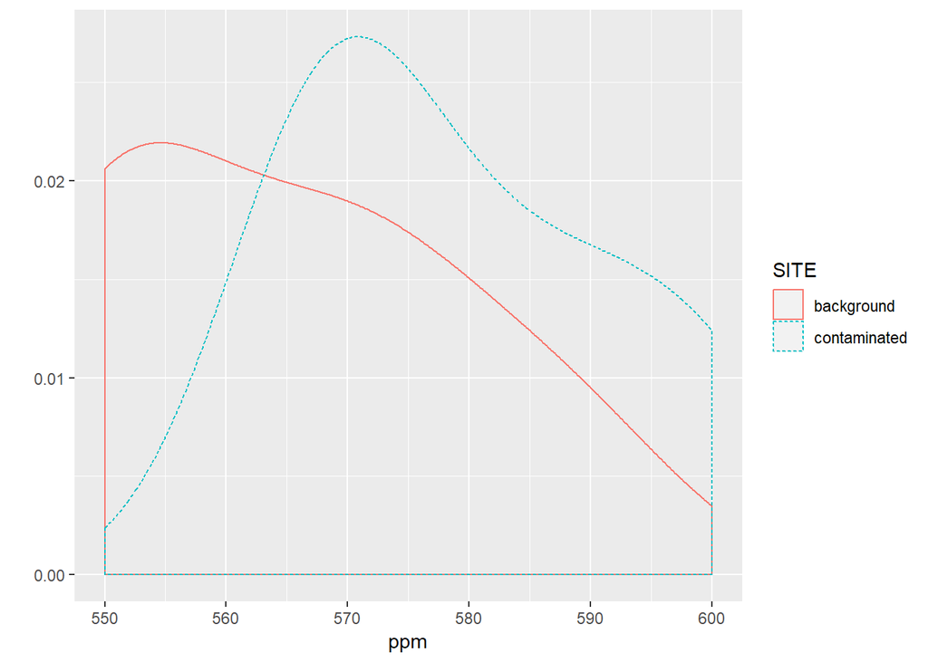

```r
qplot(ppm, data=ssulfconc, geom="density", color=SITE, linetype=SITE)
```

## CONLUSION

One SE is 14.5*sqrt(1/6 + 1/8) = 7.8 ppm, therefore our observed difference of 14.2 ppm (computed from 579.2 - 565) is 1.8SE from the expected difference of 0 (recall that for a t-test SE equals SEpooledsqrt(1/n1 + 1/n2)). Looking up the P value on a Student curve gives us a probability of 0.048 (i.e. there is 4.8% chance that, assuming there is no difference in concentration between sites, the difference means would be greater than that observed by chance variation alone).